# ACP Classification foot projet

Laurent_Chen - Patrick_Chen - Thomas_Belaid - 2AFA VCOD

2024-05-17

# Nettoyage des données

```r
# Les packages nécessaires
library(dplyr)
```

```r
library(ggplot2)
library(FactoMineR)
library(explor)
library(reshape2)
library(factoextra)
# Lecture du fichier de données
df <- read.csv("D:/BUT-2/Classification/foot.csv", sep=";", encoding="latin1")

# Supprimation des doublons basés sur la colonne player
df <- df %>% distinct(Player, .keep_all = TRUE)

# Les lignes sont les noms des joueurs
row.names(df) <- df$Player
```

Pour effectuer une analyse pertinente des performances des joueurs au cours de la saison, nous avons choisi de conserver uniquement ceux qui ont participé de manière significative. Concrètement, cela signifie que nous nous concentrons sur les joueurs ayant disputé plus de 5 matchs et ayant un temps de jeu moyen de plus de 45 minutes par match.

```r
df <- df[df$Min/df$MP >= 45 & df$MP > 5,]
```

Afin de faciliter notre analyse nous avons choisi de rassembler les postes des joueurs afin d’avoir d’un poste par joueur soit DF, soit FW , soit MF ou G.

```r
table(df$Pos)
```

```
##
##   DF DFFW DFMF   FW FWDF FWMF   GK   MF MFDF MFFW
##   89    3   10   30    1   11   18   45    6   18
```

```r
df <- df %>% mutate(Pos = recode(Pos,"DFFW" = "DF", "DFMF" = "DF", "FWDF" = "FW", "FWMF" = "FW", "MFDF" = "MF", "MFFW" = "MF"))
table(df$Pos)
```

```
##
##  DF  FW  GK  MF
## 102  42  18  69
```

Ces variables ont été supprimées car elles contenaient un nombre excessif de valeurs nulles (0). Un nombre trop élevé de valeurs nulles dans une variable signifie qu’elle ne varie pas suffisamment pour fournir des informations utiles ou différencier les performances des joueurs. Ainsi, leur pertinence pour l’analyse est grandement diminuée, rendant ces variables peu utiles pour notre étude.

```r
df <- df %>% select(-Off, -Err, -PasShoCmp.,-PasMedCmp.,-PasLonCmp., -Born)
```

```r
df$Get_ball = (df$Recov + df$Blocks + df$Int)/3
df$Recov <- NULL
df$Blocks <- NULL
df$Int <- NULL
```

On regroupe les cartons rouges et jaunes en cartons.

```r
df$Crd = (df$CrdY + df$CrdR)/2
df$CrdY <- NULL
df$CrdR <- NULL
```

On crée un dataframe avec seulement les variables quantitatives.

```r
df_quanti <- df %>% select(-Pos, -Squad)
summary(df_quanti)
```

```
##     Player               Age              MP             Min
##  Length:231         Min.   :18.00   Min.   : 6.00   Min.   : 324
##  Class :character   1st Qu.:24.50   1st Qu.:14.00   1st Qu.: 898
##  Mode  :character   Median :27.00   Median :17.00   Median :1181
##                     Mean   :27.53   Mean   :16.16   Mean   :1180
##                     3rd Qu.:30.00   3rd Qu.:19.50   3rd Qu.:1468
##                     Max.   :38.00   Max.   :23.00   Max.   :2070
##      Goals            Shots            SoT            ShoDist
##  Min.   : 0.000   Min.   :0.000   Min.   :0.0000   Min.   : 0.00
##  1st Qu.: 0.000   1st Qu.:0.445   1st Qu.:0.0750   1st Qu.:12.55
##  Median : 1.000   Median :0.950   Median :0.2800   Median :16.20
##  Mean   : 2.113   Mean   :1.268   Mean   :0.4532   Mean   :15.56
##  3rd Qu.: 3.000   3rd Qu.:1.920   3rd Qu.:0.6750   3rd Qu.:19.55
##  Max.   :25.000   Max.   :5.550   Max.   :2.2700   Max.   :34.10
##    PasTotCmp.        PasAss            PPA             PasAtt
##  Min.   :53.00   Min.   :0.0000   Min.   :0.0000   Min.   : 12.50
##  1st Qu.:77.40   1st Qu.:0.3050   1st Qu.:0.2800   1st Qu.: 41.00
##  Median :83.40   Median :0.8500   Median :0.7500   Median : 54.30
##  Mean   :82.07   Mean   :0.9958   Mean   :0.8995   Mean   : 53.53
##  3rd Qu.:87.10   3rd Qu.:1.5850   3rd Qu.:1.3500   3rd Qu.: 64.90
##  Max.   :95.50   Max.   :3.6000   Max.   :4.6900   Max.   :104.20
##        CK              SCA             GCA              Tkl
##  Min.   :0.0000   Min.   :0.000   Min.   :0.0000   Min.   :0.000
##  1st Qu.:0.0000   1st Qu.:1.090   1st Qu.:0.0700   1st Qu.:0.935
##  Median :0.0000   Median :2.110   Median :0.2300   Median :1.460
##  Mean   :0.4694   Mean   :2.318   Mean   :0.2831   Mean   :1.495
##  3rd Qu.:0.2300   3rd Qu.:3.355   3rd Qu.:0.4700   3rd Qu.:2.050
##  Max.   :6.2400   Max.   :6.520   Max.   :1.2600   Max.   :4.090
##       Clr           Touches           ToAtt          Carries
##  Min.   :0.000   Min.   : 20.70   Min.   :0.000   Min.   : 9.24
##  1st Qu.:0.445   1st Qu.: 52.30   1st Qu.:0.475   1st Qu.:30.15
##  Median :1.130   Median : 64.00   Median :1.060   Median :37.50
##  Mean   :1.492   Mean   : 63.19   Mean   :1.555   Mean   :38.91
##  3rd Qu.:2.310   3rd Qu.: 74.95   3rd Qu.:2.115   3rd Qu.:47.05
##  Max.   :4.650   Max.   :114.10   Max.   :8.100   Max.   :96.40
##       CPA              Rec             Crs           Get_ball
##  Min.   :0.0000   Min.   :12.10   Min.   :0.000   Min.   :0.2433
##  1st Qu.:0.0000   1st Qu.:35.10   1st Qu.:0.160   1st Qu.:1.7050
##  Median :0.1700   Median :43.90   Median :0.870   Median :2.3367
##  Mean   :0.4894   Mean   :44.09   Mean   :1.528   Mean   :2.2429
##  3rd Qu.:0.7050   3rd Qu.:52.60   3rd Qu.:2.235   3rd Qu.:2.9017
##  Max.   :3.6400   Max.   :91.50   Max.   :8.960   Max.   :4.1433
##       Crd
##  Min.   :0.00000
##  1st Qu.:0.03500
##  Median :0.08000
##  Mean   :0.08911
##  3rd Qu.:0.13000
##  Max.   :0.59500
```

```r
df_quanti2 <- select(df_quanti,-Player)
```

# Analyse de la base de donnée

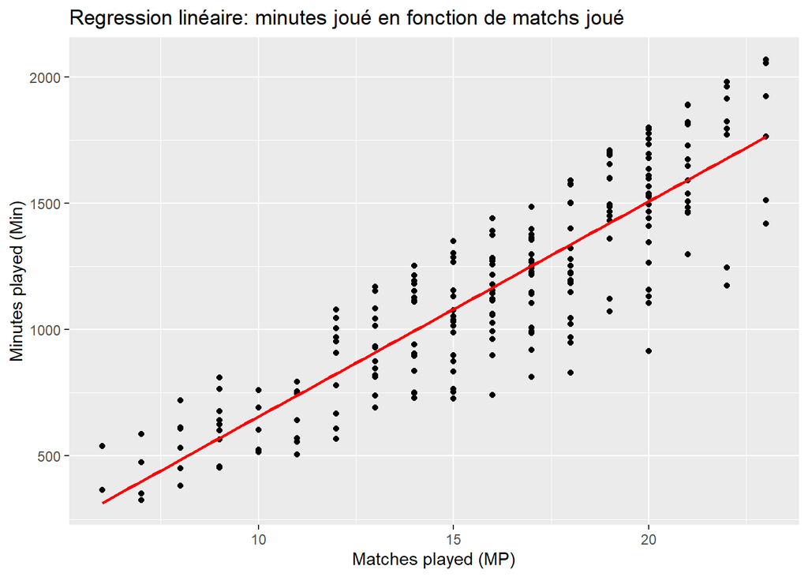

```r
# Création du modèle de régression linéaire
modele <- lm(Min ~ MP, data = df)

# Affichage du graphique pour la régression linéaire avec ggplot
ggplot(df, aes(x = MP, y = Min)) +
  geom_point() +  # Points de données
  geom_smooth(method = "lm", se = FALSE, color = "red") +  # Régression linéaire
  labs(x = "Matches played (MP)", y = "Minutes played (Min)",
       title = "Regression linéaire: minutes joué en fonction de matchs joué")
```

```r
cor(df$MP, df$Min)
```

```
## [1] 0.8713091
```

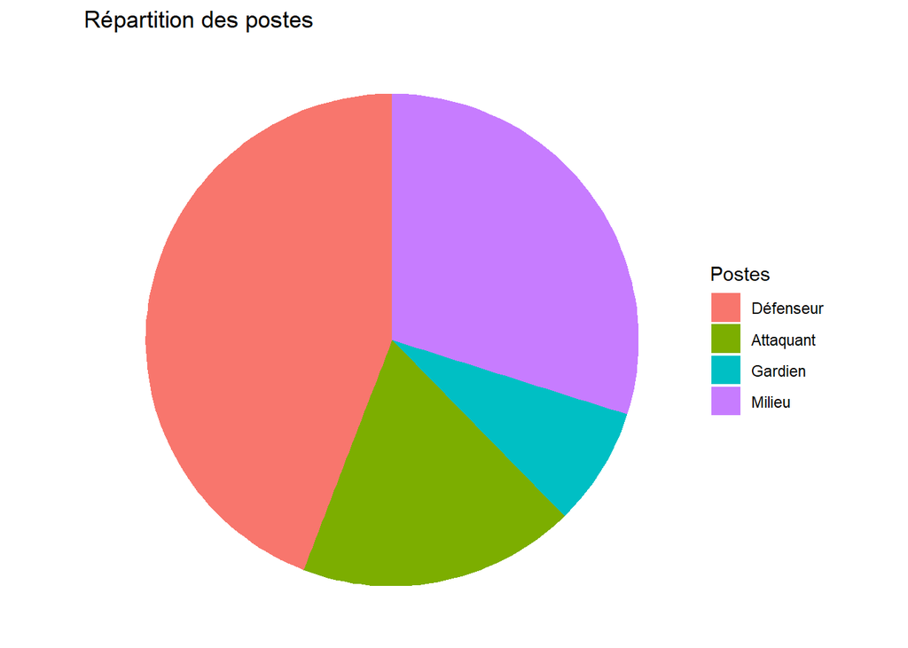

```r
# Étiquettes des parts
etiquettes <- c("Défenseur", "Attaquant", "Gardien", "Milieu")
df$Pos <- factor(df$Pos, levels = c("DF", "FW", "GK", "MF"), labels = etiquettes)
# Comptage des valeurs
valeurs <- table(df$Pos)

# Conversion de la table en dataframe
df_valeurs <- as.data.frame(valeurs)

# Création du diagramme en camembert avec ggplot
ggplot(df_valeurs, aes(x = "", y = Freq, fill = Var1)) +
  geom_bar(stat = "identity", width = 1) +
  coord_polar(theta = "y") +
  labs(title = "Répartition des postes") +
  theme_void() +
  labs(fill = "Postes")
```

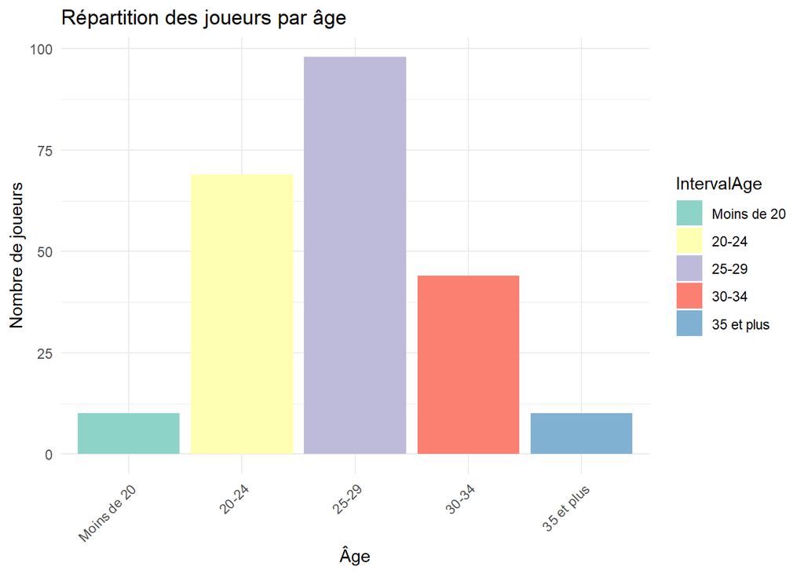

```r
# Analyse de l'age
# Création d'un vecteur pour les étiquettes d'âge
etiquettes_age <- c("Moins de 20", "20-24", "25-29", "30-34", "35 et plus")

# Définir les limites des intervalles d'âge
bornes <- c(0, 20, 25, 30, 35, max(df$Age))

# Création des intervalles d'âge avec des étiquettes
df$IntervalAge <- cut(df$Age, breaks = bornes, labels = etiquettes_age)

# Création de l'histogramme avec ggplot2
ggplot(df, aes(x = IntervalAge, fill = IntervalAge)) +
  geom_bar() +
  labs(x = "Âge", y = "Nombre de joueurs", title = "Répartition des joueurs par âge") +
  scale_fill_brewer(palette = "Set3") +  # Choix de la palette de couleurs
  theme_minimal() +
  theme(axis.text.x = element_text(angle = 45, hjust = 1))  # Rotation des étiquettes sur l'axe x
```

# Réalisation d’une ACP et interprétation

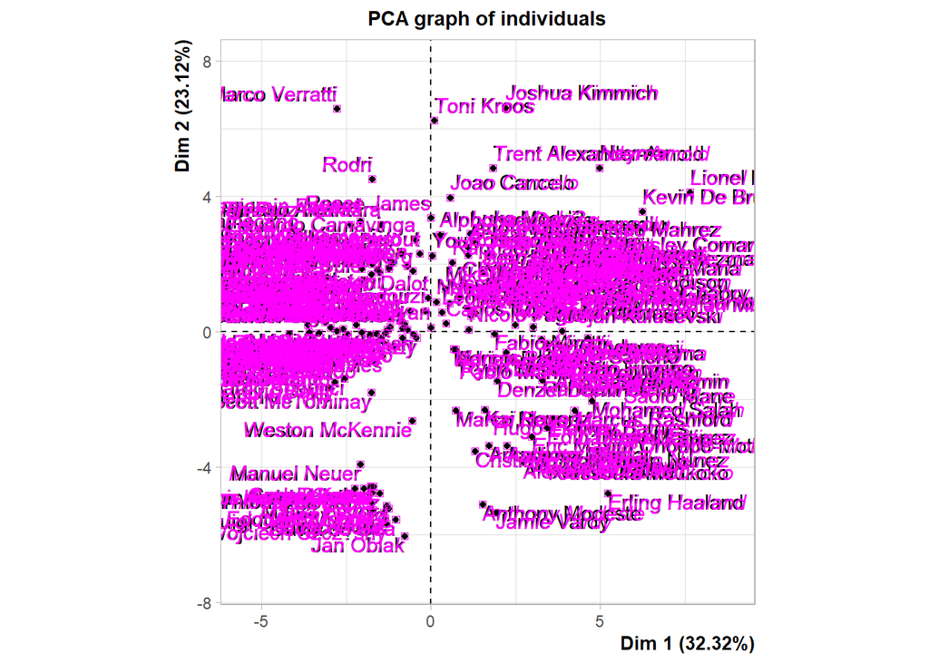

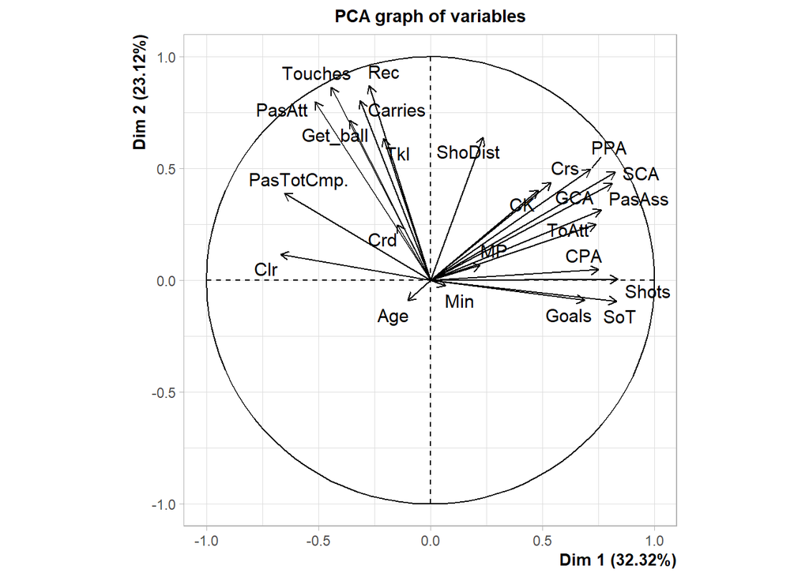

```r
nvar=ncol(df_quanti)
df_quanti.acp = PCA(df_quanti, ncp = nvar, quali.sup = 1, graph=TRUE)
```

Le graphique d’Analyse en Composantes Principales (ACP) montre les relations entre différentes variables de performance des joueurs. Les axes Dim 1 et Dim 2 expliquent respectivement 32.32 % et 23,12 % de la variance totale. Chaque flèche représente une variable, et sa direction et longueur montrent son importance et sa contribution aux deux dimensions principales. Les flèches pointant dans la même direction sont positivement corrélées, tandis que celles pointant en sens opposé sont négativement corrélées. Par exemple, les variables comme PasTotCmp, Clr, repésentant les pass et le dégagement, sont corrélées et situées à gauche, tandis que les variables offensives comme Goals, Shots, et SoT se trouvent à droite. Les flèches représentées sous forme d’angle droit ne sont pas corrélées. Par exemple, la distance de tir ShoDist n’est pas corrélée avec le nombre de but Goals. L’âge est près du centre, ce qui indique une contribution modérée. Ce graphique permet d’identifier facilement les groupes de variables qui sont liés à des aspects spécifiques de la performance des joueurs.

```r
explor(df_quanti.acp)
```

Shiny applications not supported in static R Markdown documents

```r
df_quanti.acp$eig
```

```
##           eigenvalue percentage of variance cumulative percentage of variance
## comp 1  7.7569679227           32.320699678                          32.32070
## comp 2  5.5489437770           23.120599071                          55.44130
## comp 3  2.0634019011            8.597507921                          64.03881
## comp 4  1.6422134391            6.842555996                          70.88136
## comp 5  1.4950723740            6.229468225                          77.11083
## comp 6  1.1194712064            4.664463360                          81.77529
## comp 7  0.6990471620            2.912696508                          84.68799
## comp 8  0.6679186280            2.782994283                          87.47099
## comp 9  0.5494564508            2.289401878                          89.76039
## comp 10 0.4255541628            1.773142345                          91.53353
## comp 11 0.3769357638            1.570565682                          93.10409
## comp 12 0.3302881381            1.376200576                          94.48030
## comp 13 0.2772531002            1.155221251                          95.63552
## comp 14 0.2019894979            0.841622908                          96.47714
## comp 15 0.1834331260            0.764304692                          97.24144
## comp 16 0.1662040159            0.692516733                          97.93396
## comp 17 0.1329065372            0.553777238                          98.48774
## comp 18 0.1063941677            0.443309032                          98.93105
## comp 19 0.0889006215            0.370419256                          99.30147
## comp 20 0.0583124850            0.242968688                          99.54444
## comp 21 0.0524327187            0.218469661                          99.76290
## comp 22 0.0392803869            0.163668279                          99.92657
## comp 23 0.0166683452            0.069451438                          99.99602
## comp 24 0.0009540721            0.003975301                         100.00000
```

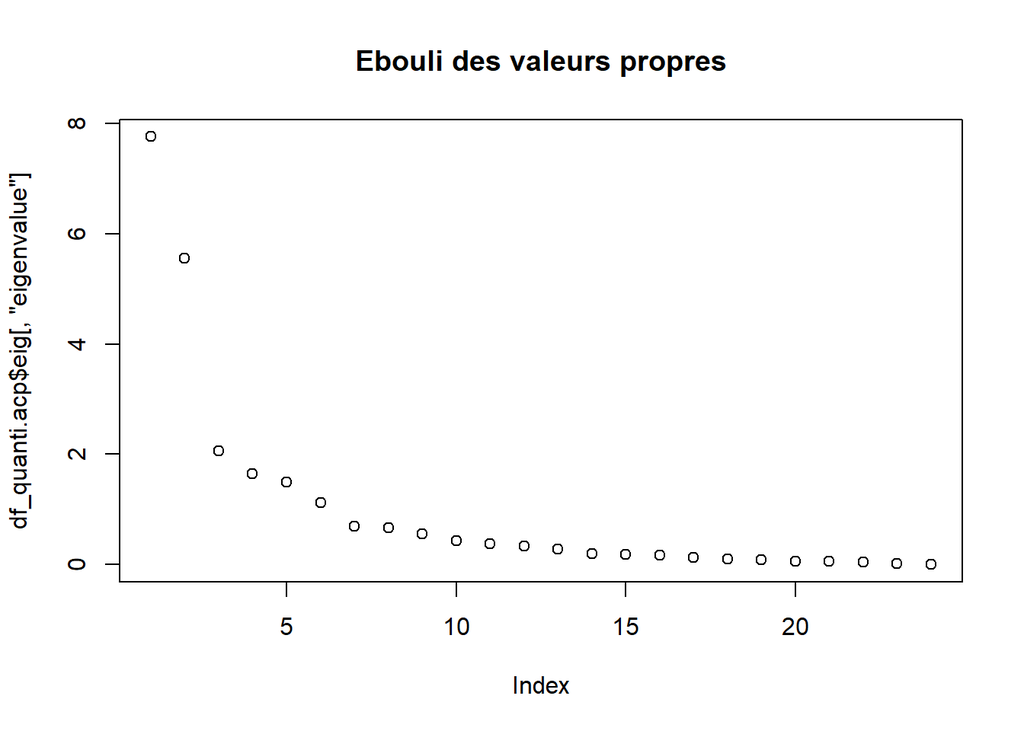

```r
plot(df_quanti.acp$eig[,'eigenvalue'], main="Ebouli des valeurs propres", names.arg=1)
```

D’après la règle de kaiser, il faut garder les axes dont la valeur des valeurs propres est supérieure à 1. D’après la règle empiriques, il faut garder les facteurs expliquant un pourcentage de variance cumulé à 80%. D’après l’éboulis des valeurs propres, il faut garder les axes correspondant aux valeurs propres situées avant le point d’inflexion. **Dans les trois cas, on doit conserver 6 axes, mais nous allons en analyser que 4.**

## Axe 1

Les variables qui représentent le mieux l’axe 1 sont SCA, PasAss, Shots, SoT, GCA, ToAtt, PPA, CPA. Ces variables sont tous en lien avec un jeu offensif comme les attaquants. **Donc on peut dire que les joueurs qui sont à droite du cercle sont les joueurs ayant un style de jeu offensif. Et les joueurs à gauche du cercle ont un style de jeu peu offensif.** Le joueur offensif qui se démarque le plus est Lionnel Messi, ou encore Kylian Mbappe. De l’autre côté, on a le défenseur Victor Lindelof qui est peu offensif.

## Axe 2

Les variables qui représentent le mieux l’axe 2 sont Rec, Touches, PasAtt, Carries. Ces variables sont fortement en lien avec un jeu qui contrôle beaucoup le ballon comme les milieux de terrain. **Donc on peut dire que les joueurs qui sont en haut du cercle sont les joueurs qui contrôlent beaucoup le ballon. Et les joueurs en bas du cercle contrôlent peu le ballon.** Par exemple, le joueur Marco Verrati contrôle beaucoup le ballon. Alors que Jan Oblak possède peu le ballon.

## Axe 3

Les variables qui représentent le mieux l’axe 3 sont Min, MP. Ces variables renvoient aux joueurs qui ont le plus joué. **Donc on peut dire que les joueurs qui sont en haut du cercle sont les joueurs qui ont le plus joué. Et les joueurs en bas du cercle ont le moins joué.** Par exemple, le joueur David de Gea a beaucoup joué. Alors que Pablo Marin a peu joué.

## Axe 4

Les variables qui représentent le mieux l’axe 4 sont Crs, CK. Ces variables renvoient aux joueurs qui font un grand nombre de centre. **Donc on peut dire que les joueurs qui sont en bas du cercle sont les joueurs qui font le plus de centre. Et les joueurs en haut du cercle ont fait peu de centre.** Par exemple, Ivan Perisi fait le plus de centre. Alors que Kylian Mbappe a fait le moins.

# Classification et interprétation

```r
# CAH et dendrogramme
x.std = scale(df_quanti2) #centré reduit

distance=dist(x.std, method="euclidean")
```

On utilise la méthode de ward.D2 pour faire le dendogramme. C’est la méthode la plus fiable.

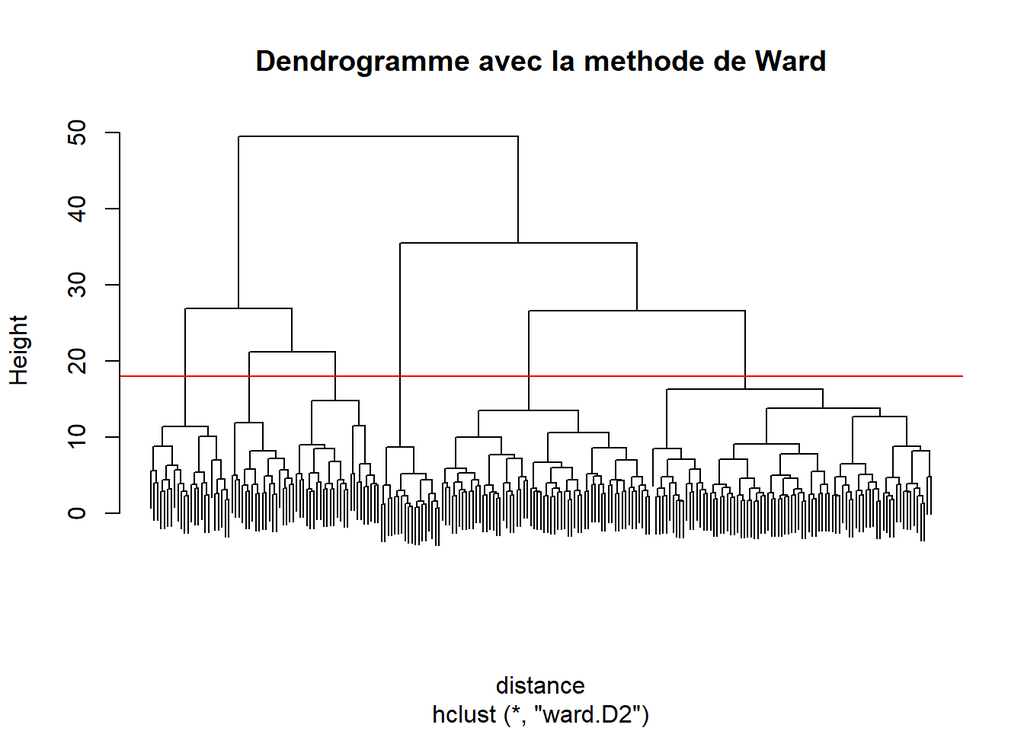

```r
dendro=hclust(distance, method="ward.D2")
plot(dendro, main = "Dendrogramme avec la methode de Ward", label=FALSE)
abline(h=18, col="red")
```

Visuellement, on aurait envie de couper avec le trait rouge (6 clusters).

Pour être sûr de nous, nous allons utiliser une fonction qui nous permet d’obtenir deux indicateurs efficaces dans notre situation : le R² et le pseudo-F.

Le R², ou coefficient de détermination, mesure la proportion de la variance des données expliquée par le modèle. Il varie de 0 à 1, avec 1 indiquant une parfaite explication des données par le modèle. Le pseudo-F est utilisé dans les analyses de clusters pour évaluer la qualité de la partition des données, en comparant la variance inter-clusters à la variance intra-cluster. Un pseudo-F élevé indique une bonne séparation des clusters.

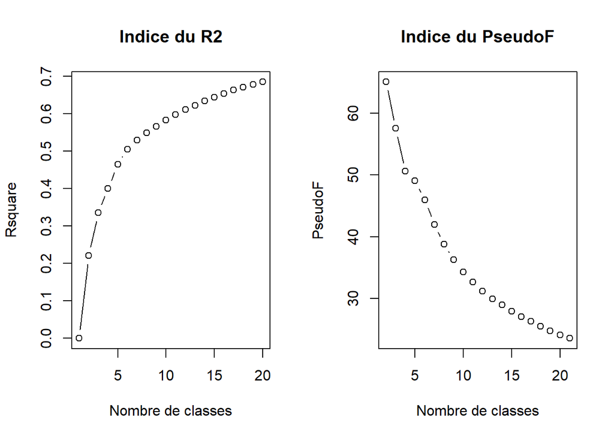

```
## $Rsquare
##   [1] 0.0000000 0.2211536 0.3352553 0.4005804 0.4645403 0.5050802 0.5292071
##   [8] 0.5491461 0.5664977 0.5829313 0.5976616 0.6105539 0.6224683 0.6343405
##  [15] 0.6445583 0.6537525 0.6628738 0.6704383 0.6778343 0.6849116 0.6919354
##  [22] 0.6988325 0.7055823 0.7121498 0.7186794 0.7248474 0.7309393 0.7365232
##  [29] 0.7419584 0.7467311 0.7514624 0.7561010 0.7606867 0.7651505 0.7695623
##  [36] 0.7738143 0.7778720 0.7817690 0.7856571 0.7892475 0.7924927 0.7956414
##  [43] 0.7987414 0.8018120 0.8047890 0.8077430 0.8106191 0.8134205 0.8161043
##  [50] 0.8187008 0.8212901 0.8238047 0.8263080 0.8287746 0.8312209 0.8336362
##  [57] 0.8359207 0.8381975 0.8404659 0.8426537 0.8448100 0.8469472 0.8490564
##  [64] 0.8511359 0.8532126 0.8552860 0.8572788 0.8592515 0.8612215 0.8631428
##  [71] 0.8650263 0.8668375 0.8686468 0.8704402 0.8722332 0.8740152 0.8757888
##  [78] 0.8775611 0.8793011 0.8810143 0.8826953 0.8842512 0.8857979 0.8873400
##  [85] 0.8888588 0.8903595 0.8918468 0.8933270 0.8947922 0.8962539 0.8977080
##  [92] 0.8991400 0.9005664 0.9019784 0.9033885 0.9047724 0.9061445 0.9075117
```

[output cut: 54 more lines]

```r
R2.PseudoF = function(donnees,dendro, graph=T, cut=20){
  n=nrow(donnees)
  R2 = numeric(n)

  Iinter = 0
  g = apply(donnees, 2, mean)
  I = (n-1)/n*sum(diag(var(donnees)))

  for(i in 2:n){
      class = cutree(dendro,k=i)
      ncl = unique(class)
      d = numeric(length(ncl))
      nb = integer(length(ncl))
      for(j in ncl){
          nb[j] = sum(class==j)
          if(nb[j]>1){
              m = apply(donnees[class==j,], 2, mean)
          } else {
              m = donnees[class==j,]
          }
          d[j] = sum((m-g)^2)
      }
      Iinter = (1/n)*sum(nb*d)
      R2[i] = Iinter/I
  }

  ncl = 2:(n-1)
  PseudoF = R2[ncl]/(1-R2[ncl])*(n-ncl)/(ncl-1)

  if(graph==T){
  par(mfrow=c(1,2))
  plot(1:20,R2[1:cut], type = 'b', xlab = "Nombre de classes", ylab = "Rsquare")
  title("Indice du R2")
  plot(ncl[1:20],PseudoF[1:cut], type = 'b', xlab = "Nombre de classes", ylab = "PseudoF")
  title("Indice du PseudoF")
  }
  resultat = list(R2,PseudoF)
  names(resultat)=c("Rsquare","PseudoF")
  resultat
}

R2.PseudoF(x.std,dendro)
```

D’après l’analyse du coefficient de détermination (R²), le point de rupture semble être à 6, ce qui maximise l’ajustement du modèle aux données. Cependant, le pseudo-F, qui évalue la qualité de cette partition, n’est pas stable à ce niveau, indiquant une possible fragilité de ce point de rupture et suggérant qu’une réévaluation pourrait être nécessaire.

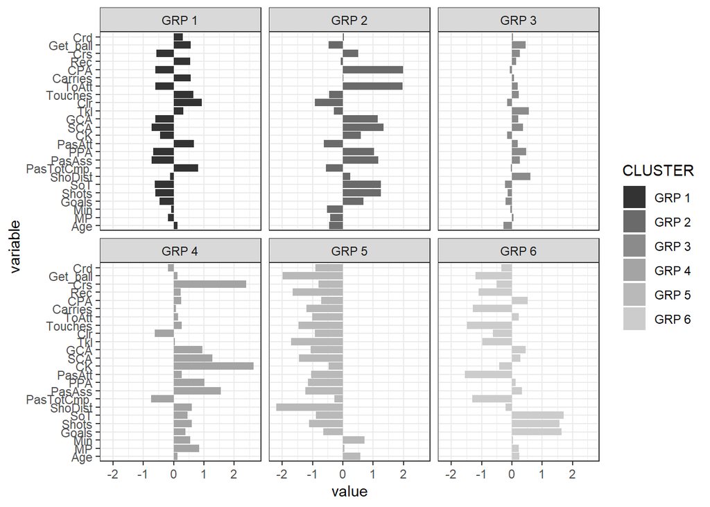

```r
################################### A PEAUFINER  ####################################################
res = cutree(dendro, 6)
df2 <- as.data.frame(x.std)
df$Cluster <- factor(res,
                     levels = 1:6,
                     labels = paste("GRP", 1:6))
clusProfile <- aggregate(df2[, 1:24],
                         by = list(df$Cluster),
                         mean)
colnames(clusProfile)[ 1] <- "CLUSTER"
clus_transpose <- melt(clusProfile, id.vars = "CLUSTER") #transposition du df

ggplot(clus_transpose) +
  geom_bar(aes(x = variable, y = value, fill = CLUSTER),
           stat = "identity") +
  scale_fill_grey() +
  facet_wrap(~ CLUSTER) +
  coord_flip() + theme_bw()
```

Cluster 2 :

D’autre part, les variables SCA, PasAss, Shots, SoT, GCA, ToAtt, PPA et CPA représentent le mieux l’axe 1. Elles sont toutes associées à un jeu offensif, souvent caractéristique des attaquants.

Cluster 3 :

Ces joueurs semblent être des acteurs importants dans la création et la transition du jeu, avec une contribution notable dans les phases défensives et offensives.

Cluster 4 :

Cluster 5 :

Les variables Age,MP et Min sont les seuls avec un moyenne positif.

Ce cluster regroupe les joueurs les plus âgés de la compétition, ayant accumulé une expérience considérable sur le terrain. Leurs statistiques de matchs joués et de temps de jeu reflètent une longue carrière dans le football.( Pour résumer les joueurs les plus anciens de la compétition)

Cluster 6 :

Les variables avec les moyennes les plus élévés sont Goals , Shots , SoT.

Ce cluster se caractérise par des moyennes élevées dans les catégories des buts marqués, des tirs et des tirs cadrés. Il semble regrouper les joueurs ayant réalisé le plus de réalisations au cours de la compétition, mettant en lumière leur rôle prépondérant en tant qu’attaquants.

```r
profils = function(donnees,classes){
  nvar=ncol(donnees)
  class=unique(classes)
  nclass=length(class)

  moyenne = matrix(nrow=nvar,ncol=nclass)
  ecart = matrix(nrow=nvar,ncol=nclass)

  rownames(moyenne)=colnames(donnees)
  colnames(moyenne)=class

  rownames(ecart)=colnames(donnees)
  colnames(ecart)=class

  for(i in 1:nclass){
   moyenne[,i] = apply(donnees[classes==class[i],],2,mean)
   ecart[,i] = sqrt(apply(donnees[classes==class[i],],2,var))
  }
  resultat = list(moyenne, colMeans(donnees, na.rm=T), ecart)
  names(resultat)=c("Cluster.Centers", "Average.point", "Cluster.std")
  resultat
}

stats = profils(df_quanti2, cutree(dendro,6))
(stats$Cluster.Centers-stats$Average.point)/stats$Cluster.std
```

```
##                     1           2           3           4           5
## Age         0.1529410 -0.43523214 -0.27919200  0.15646150   0.6252951
## MP         -0.1906594 -0.39128617  0.06414968  1.77726085   0.0458975
## Min        -0.0938412 -0.51897253 -0.06199317  1.06857425   0.6066571
## Goals      -1.7610120  0.57360448 -0.41959431  0.48962707        -Inf
## Shots      -1.8652715  1.41849226 -0.27154192  0.81917251 -31.4182650
## SoT        -2.1576776  1.31009069 -0.47627240  0.59127551 -23.7990409
## ShoDist    -0.1320647  0.59602631  0.92155687  1.06622398  -7.0973930
## PasTotCmp.  1.5226941 -0.98071110 -0.06178217 -0.85489446  -0.2845094
## PasAss     -1.7849701  1.50711016  0.41946359  2.45094457 -33.4373661
## PPA        -1.5599327  0.86513110  0.73393450  1.10465522 -76.0877507
## PasAtt      0.9086834 -1.07718561  0.29580446  0.25309763  -4.0460115
## CK         -4.6520946  0.56615250 -0.28743921  2.62035752        -Inf
## SCA        -1.7038483  1.93667563  0.69711822  2.01113332 -28.7108886
## GCA        -1.2624211  0.96915645  0.26240593  1.00027189 -14.3286989
## Tkl         0.3321414 -0.49400218  0.80977749  0.06281669 -35.5842202
## Clr         0.9998354 -3.54572427 -0.24153230 -1.59249879  -6.6597240
## Touches     0.9355639 -0.78375330  0.37563629  0.27008943  -5.5701489
## ToAtt      -1.5850203  2.15796265  0.25045560  0.24736027 -54.7487374
## Carries     0.6035681  0.02706120  0.09775671  0.08187295  -4.2619333
## CPA        -3.1142153  1.54577661 -0.11696467  0.32531115        -Inf
## Rec         0.6413114 -0.09959408  0.19527930  0.24565645  -5.8687239
## Crs        -1.9447467  0.63865239  0.38819666  2.45570744        -Inf
## Get_ball    0.9486269 -0.75503999  0.64983623  0.19236303 -14.9617874
## Crd         0.2575816  0.03498329  0.03974549 -0.24853372  -2.8891803
##                      6
## Age         0.18113583
## MP          0.21268990
## Min         0.02454072
## Goals       1.02173715
## Shots       1.94698054
## SoT         2.26384464
## ShoDist    -0.85027133
## PasTotCmp. -1.23151926
## PasAss      0.50903800
## PPA         0.14015274
## PasAtt     -2.99823686
## CK         -3.54921742
## SCA         0.40210148
## GCA         0.53696163
## Tkl        -2.31926099
## Clr        -1.39790127
## Touches    -2.80327729
## ToAtt       0.38650438
## Carries    -2.54761627
## CPA         0.70494188
## Rec        -1.90166280
## Crs        -2.21347927
## Get_ball   -3.03333409
## Crd        -0.42508805
```

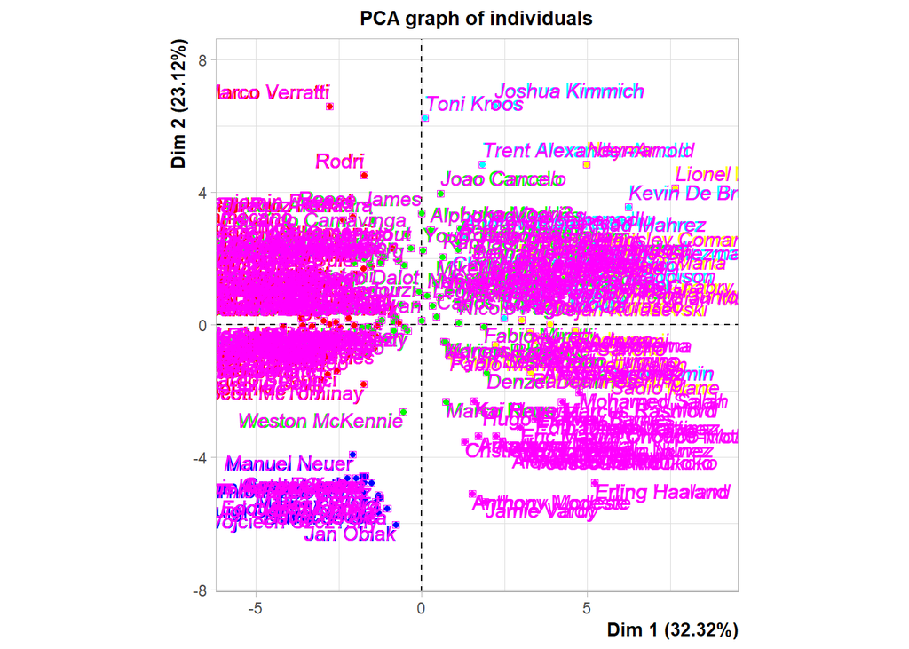

```r
plot(df_quanti.acp, choix="ind", habillage = "ind", col.hab=rainbow(6)[cutree(dendro,6)])
```

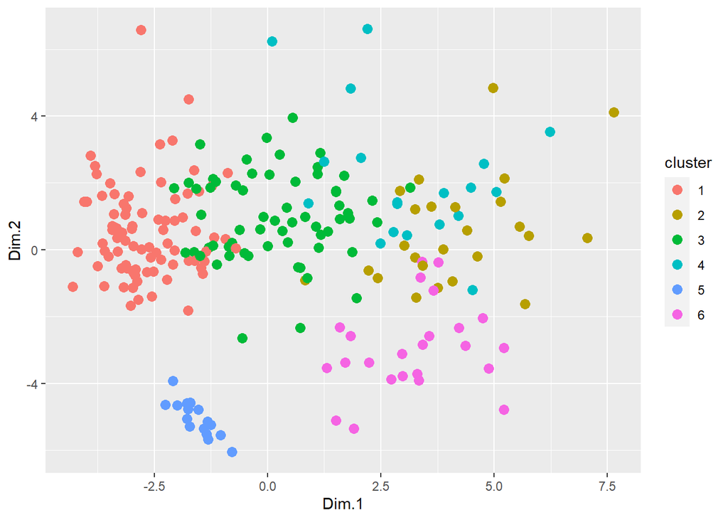

```r
clusters <- cutree(dendro, 6)

# Créer le graphique ACP avec les clusters et sans les labels
df_pca <- data.frame(df_quanti.acp$ind$coord, cluster = as.factor(clusters))

# Créer le graphique PCA avec ggplot2 pour personnaliser les formes et les couleurs
ggplot(df_pca, aes(x = Dim.1, y = Dim.2, color = cluster)) +
  geom_point(size = 3)
```

Nous allons commencer par une analyse de la localisation des clusters :

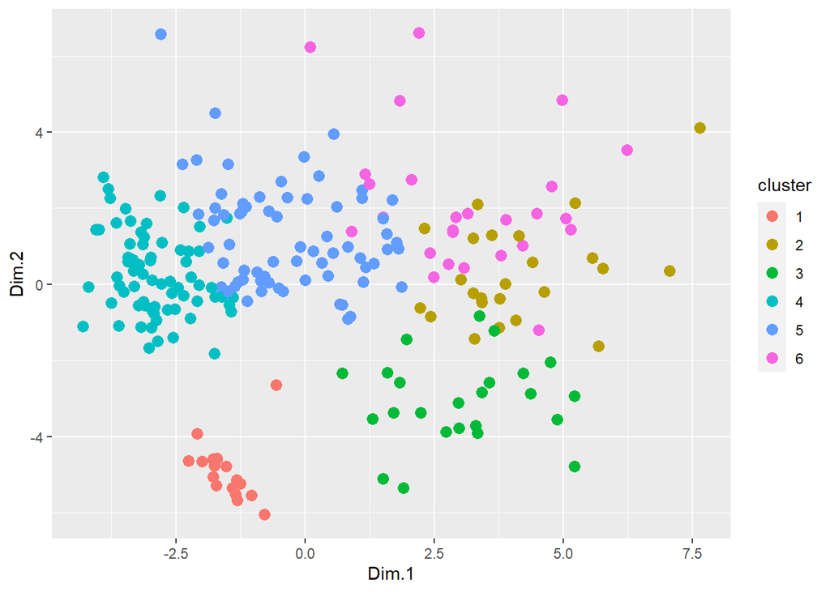

```r
# Effectuer le k-means clustering avec k=6 classes
df.km <- kmeans(x.std, 6, nstart = 10)

# Extraire les coordonnées des individus de l'ACP
coord <- as.data.frame(df_quanti.acp$ind$coord)
coord$cluster <- as.factor(df.km$cluster)

# Créer le graphique PCA avec ggplot2
ggplot(coord, aes(x = Dim.1, y = Dim.2, color = cluster)) +
  geom_point(size = 3)
```

Ce graphique a été réalisé à partir de la méthode des k-means. L’objectif principal de la méthode des K-means est de partitionner un jeu de données en k clusters distincts. Chaque point de données est assigné au cluster dont le centroïde (le centre du cluster) est le plus proche. L’objectif est de minimiser la variance intra-cluster, c’est-à-dire de rendre les points de chaque cluster aussi similaires que possible tout en maximisant les différences entre les clusters. Les points centraux (centroïdes) sont initialement fixés aléatoirement, ce qui peut influencer les résultats finaux. Bien que la méthode des k-means et l’ACP aient des approches différentes pour le clustering, on remarque que nos 6 groupes d’individus sont, à quelques individus près, identiques.